# 重賞レース予測レポート【毎時自動更新中】

作成日時: 2026/04/12 10:06:30

☞ [マニュアル(pdf)](https://ryutoro-galois.github.io/keiba-predictor/manual/manual.pdf)

☞ 過去6年の同一レース結果: [2025年](https://ryutoro-galois.github.io/keiba-predictor/report/PredResult_2025y_raceDate_20250412_20250413.html), [2024年](https://ryutoro-galois.github.io/keiba-predictor/report/PredResult_2024y_raceDate_20240406_20240407.html), [2023年](https://ryutoro-galois.github.io/keiba-predictor/report/PredResult_2023y_raceDate_20230408_20230409.html), [2022年](https://ryutoro-galois.github.io/keiba-predictor/report/PredResult_2022y_raceDate_20220409_20220410.html), [2021年](https://ryutoro-galois.github.io/keiba-predictor/report/PredResult_2021y_raceDate_20210410_20210411.html), [2020年](https://ryutoro-galois.github.io/keiba-predictor/report/PredResult_2020y_raceDate_20200411_20200412.html)

☞ 過去4週間の別レース結果: [1週前(4/4-5)](https://ryutoro-galois.github.io/keiba-predictor/report/PredResult_2026y_raceDate_20260404_20260405.html), [2週前(3/28-29)](https://ryutoro-galois.github.io/keiba-predictor/report/PredResult_2026y_raceDate_20260328_20260329.html), [3週前(3/21-22)](https://ryutoro-galois.github.io/keiba-predictor/report/PredResult_2026y_raceDate_20260321_20260322.html), [4週前(3/14-15)](https://ryutoro-galois.github.io/keiba-predictor/report/PredResult_2026y_raceDate_20260314_20260315.html)

☞ netkeiba: [ニュージーランドT(GⅡ)](https://race.netkeiba.com/race/shutuba.html?race_id=202606030511&rf=race_list), [阪神牝馬ステークス(GⅡ)](https://race.netkeiba.com/race/shutuba.html?race_id=202609020511&rf=race_list), [桜花賞(GⅠ)](https://race.netkeiba.com/race/shutuba.html?race_id=202609020611&rf=race_list)

## 0. 推し馬予測 (AI予測)

### 【ニュージーランドT(GⅡ) 2026/04/11(土)】

- 本命(◎): 1-3着内確率(勝負強さ)が1位の馬
- 対抗(◯): 1-3着内確率が2-N位(20%程度以上)の中で予測タイムが最も速い馬
- 3番手(▲): 1-3着内確率が2-N位(20%程度以上)のでダークホース確率が最も高い馬
- 穴: ダークホース確率が上位1-M位(40%程度以上)の中で1-3着内確率が最も高い馬

| 推し馬 | 枠番 | 馬番 | 人気 | オッズ | 馬名 | 騎手 | 調教師 | 予測タイム(sec) | 1_順位 | 1-3着内確率(%) | 2_順位 | ﾀﾞｰｸﾎｰｽ確率(%) | 3_順位 |
| --- | --- | --- | --- | --- | --- | --- | --- | --- | --- | --- | --- | --- | --- |
| 本命(◎) | 6 | 11 | 2 | 3.7 | ゴーラッキー | 横山武史 | 黒岩陽一 | 97.6 | 9 | 42.7 | 1 | 0.5 | 13 |
| 対抗(◯) | 3 | 5 | 4 | 11.8 | ジーネキング | 横山和生 | 斎藤誠 | 94.6 | 3 | 28.4 | 3 | 0.9 | 11 |
| 3番手(▲) | 3 | 4 | 5 | 13.3 | ヒズマスターピース | 佐々木大輔 | 奥村武 | 94.6 | 4 | 26.7 | 4 | 0.8 | 12 |
| 穴 | 8 | 15 | 15 | 437.6 | ミリオンクラウン | 柴田大知 | 和田雄二 | 94.8 | 6 | 5.5 | 12 | 44.8 | 1 |

### 【阪神牝馬ステークス(GⅡ) 2026/04/11(土)】

- 本命(◎): 1-3着内確率(勝負強さ)が1位の馬
- 対抗(◯): 1-3着内確率が2-N位(20%程度以上)の中で予測タイムが最も速い馬
- 3番手(▲): 1-3着内確率が2-N位(20%程度以上)のでダークホース確率が最も高い馬
- 穴: ダークホース確率が上位1-M位(40%程度以上)の中で1-3着内確率が最も高い馬

| 推し馬 | 枠番 | 馬番 | 人気 | オッズ | 馬名 | 騎手 | 調教師 | 予測タイム(sec) | 1_順位 | 1-3着内確率(%) | 2_順位 | ﾀﾞｰｸﾎｰｽ確率(%) | 3_順位 |
| --- | --- | --- | --- | --- | --- | --- | --- | --- | --- | --- | --- | --- | --- |
| 本命(◎) | 6 | 6 | 2 | 3.3 | アスコリピチェーノ | 坂井瑠星 | 黒岩陽一 | 89.0 | 5 | 39.2 | 1 | 0.5 | 9 |
| 対抗(◯) | 5 | 5 | 4 | 7.8 | カムニャック | 川田将雅 | 友道康夫 | 85.2 | 2 | 24.4 | 2 | 0.9 | 7 |
| 3番手(▲) | 2 | 2 | 6 | 14.1 | カピリナ | 横山典弘 | 田島俊明 | 89.2 | 6 | 15.3 | 4 | 28.0 | 3 |
| 穴 | 8 | 10 | 9 | 73.4 | ビップデイジー | 西村淳也 | 松下武士 | 88.6 | 4 | 5.2 | 8 | 44.8 | 1 |

### 【桜花賞(GⅠ) 2026/04/12(日)】

- 本命(◎): 1-3着内確率(勝負強さ)が1位の馬
- 対抗(◯): 1-3着内確率が2-N位(20%程度以上)の中で予測タイムが最も速い馬
- 3番手(▲): 1-3着内確率が2-N位(20%程度以上)のでダークホース確率が最も高い馬
- 穴: ダークホース確率が上位1-M位(40%程度以上)の中で1-3着内確率が最も高い馬

| 推し馬 | 枠番 | 馬番 | 人気 | オッズ | 馬名 | 騎手 | 調教師 | 予測タイム(sec) | 1_順位 | 1-3着内確率(%) | 2_順位 | ﾀﾞｰｸﾎｰｽ確率(%) | 3_順位 |
| --- | --- | --- | --- | --- | --- | --- | --- | --- | --- | --- | --- | --- | --- |
| 本命(◎) | 7 | 14 | 1 | 3.1 | ドリームコア | Ｃ．ルメール | 萩原清 | 92.7 | 1.0 | 41.9 | 1 | 1.5 | 16 |
| 対抗(◯) | 7 | 15 | 2 | 3.4 | スターアニス | 松山弘平 | 高野友和 | 95.7 | 5.0 | 24.7 | 5 | 1.6 | 15 |
| 3番手(▲) | 3 | 5 | 5 | 15.6 | ギャラボーグ | 西村淳也 | 杉山晴紀 | 97.9 | 10.5 | 22.5 | 6 | 2.2 | 12 |
| 穴 | 8 | 16 | 17 | 195.1 | ショウナンカリス | 池添謙一 | 加藤士津八 | 92.8 | 2.5 | 14.4 | 8 | 67.3 | 1 |

## 1. 予測チャート (タイム/勝負強さ)

### 【ニュージーランドT(GⅡ)】

2026/04/11(土), 06_中山, 芝右外1600m

[interactive chart not shown]

### 【阪神牝馬ステークス(GⅡ)】

2026/04/11(土), 09_阪神, 芝右外1600m

[interactive chart not shown]

### 【桜花賞(GⅠ)】

2026/04/12(日), 09_阪神, 芝右外1600m

[interactive chart not shown]

## 2. オッズモニタリング (毎時)

### 【ニュージーランドT】

[interactive chart not shown]

### 【阪神牝馬ステークス】

[interactive chart not shown]

### 【桜花賞】

[interactive chart not shown]

## 3. 出馬表

### 【ニュージーランドT 2026/04/11(土) 】

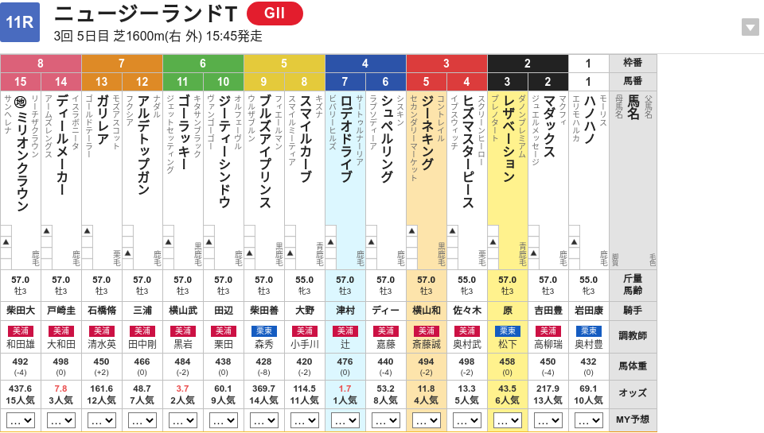

### 【阪神牝馬ステークス 2026/04/11(土) 】

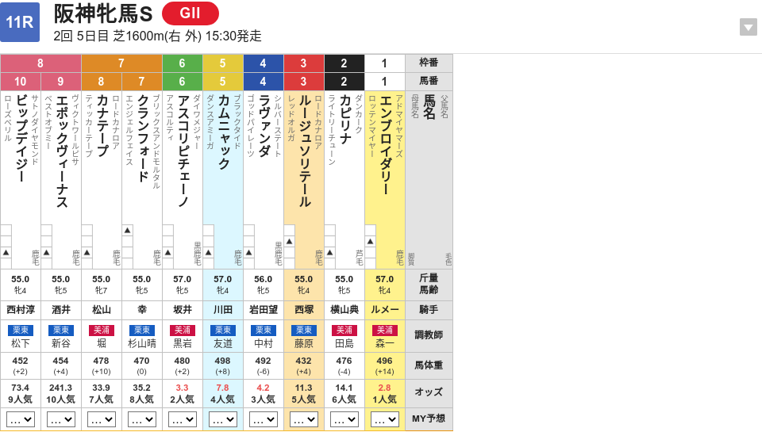

### 【桜花賞 2026/04/12(日) 】

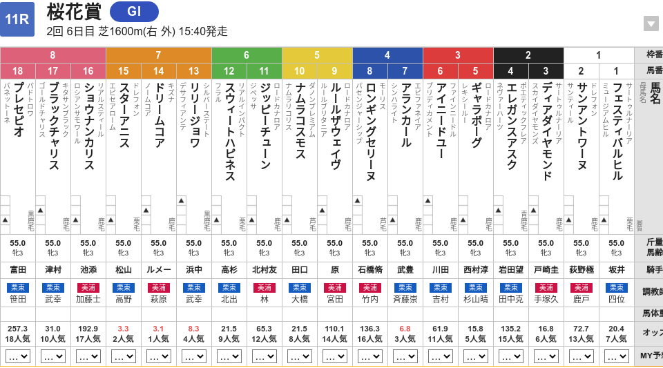

## 4. 単勝予測結果

### 【ニュージーランドT(GⅡ) 2026/04/11(土)】

| 枠番 | 馬番 | 人気 | オッズ | 馬名 | 騎手 | 調教師 | 予測タイム(sec) | 1_順位 | 1-3着内確率(%) | 2_順位 | ﾀﾞｰｸﾎｰｽ確率(%) | 3_順位 |
| --- | --- | --- | --- | --- | --- | --- | --- | --- | --- | --- | --- | --- |
| 1 | 1 | 10 | 69.1 | ハノハノ | 岩田康誠 | 奥村豊 | 92.9 | 1.5 | 9.7 | 7 | 38.0 | 3 |
| 2 | 2 | 13 | 217.9 | マダックス | 吉田豊 | 高柳瑞樹 | 104.7 | 13.0 | 3.1 | 13 | 14.5 | 7 |
| 2 | 3 | 6 | 43.5 | レザベーション | 原優介 | 松下武士 | 105.4 | 15.0 | 10.0 | 6 | 1.4 | 8 |
| 3 | 4 | 5 | 13.3 | ヒズマスターピース | 佐々木大輔 | 奥村武 | 94.6 | 4.0 | 26.7 | 4 | 0.8 | 12 |
| 3 | 5 | 4 | 11.8 | ジーネキング | 横山和生 | 斎藤誠 | 94.6 | 3.0 | 28.4 | 3 | 0.9 | 11 |
| 4 | 6 | 8 | 53.2 | シュペルリング | Ｍ．ディー | 嘉藤貴行 | 94.7 | 5.0 | 8.9 | 8 | 1.1 | 10 |
| 4 | 7 | 1 | 1.7 | ロデオドライブ | 津村明秀 | 辻哲英 | 92.9 | 1.5 | 16.4 | 5 | 0.5 | 14 |
| 5 | 8 | 11 | 114.5 | スマイルカーブ | 大野拓弥 | 小手川準 | 104.6 | 12.0 | 2.7 | 14 | 19.4 | 6 |
| 5 | 9 | 14 | 369.7 | ブルズアイプリンス | 柴田善臣 | 森秀行 | 105.1 | 14.0 | 1.8 | 15 | 38.4 | 2 |
| 6 | 10 | 9 | 60.1 | ジーティーシンドウ | 田辺裕信 | 栗田徹 | 103.9 | 11.0 | 5.6 | 11 | 29.1 | 5 |

[output cut: 5 more lines]

### 【阪神牝馬ステークス(GⅡ) 2026/04/11(土)】

| 枠番 | 馬番 | 人気 | オッズ | 馬名 | 騎手 | 調教師 | 予測タイム(sec) | 1_順位 | 1-3着内確率(%) | 2_順位 | ﾀﾞｰｸﾎｰｽ確率(%) | 3_順位 |
| --- | --- | --- | --- | --- | --- | --- | --- | --- | --- | --- | --- | --- |
| 1 | 1 | 1 | 2.8 | エンブロイダリー | Ｃ．ルメール | 森一誠 | 80.2 | 1 | 14.9 | 5 | 0.5 | 8 |
| 2 | 2 | 6 | 14.1 | カピリナ | 横山典弘 | 田島俊明 | 89.2 | 6 | 15.3 | 4 | 28.0 | 3 |
| 3 | 3 | 5 | 11.3 | ルージュソリテール | 西塚洸二 | 藤原英昭 | 88.2 | 3 | 18.5 | 3 | 1.0 | 6 |
| 4 | 4 | 3 | 4.2 | ラヴァンダ | 岩田望来 | 中村直也 | 100.0 | 10 | 13.3 | 6 | 0.5 | 10 |
| 5 | 5 | 4 | 7.8 | カムニャック | 川田将雅 | 友道康夫 | 85.2 | 2 | 24.4 | 2 | 0.9 | 7 |
| 6 | 6 | 2 | 3.3 | アスコリピチェーノ | 坂井瑠星 | 黒岩陽一 | 89.0 | 5 | 39.2 | 1 | 0.5 | 9 |
| 7 | 7 | 8 | 35.2 | クランフォード | 幸英明 | 杉山晴紀 | 97.1 | 7 | 10.1 | 7 | 30.9 | 2 |
| 7 | 8 | 7 | 33.9 | カナテープ | 松山弘平 | 堀宣行 | 97.8 | 9 | 2.1 | 9 | 10.4 | 5 |
| 8 | 9 | 10 | 241.3 | エポックヴィーナス | 酒井学 | 新谷功一 | 97.5 | 8 | 1.7 | 10 | 17.7 | 4 |
| 8 | 10 | 9 | 73.4 | ビップデイジー | 西村淳也 | 松下武士 | 88.6 | 4 | 5.2 | 8 | 44.8 | 1 |

### 【桜花賞(GⅠ) 2026/04/12(日)】

| 枠番 | 馬番 | 人気 | オッズ | 馬名 | 騎手 | 調教師 | 予測タイム(sec) | 1_順位 | 1-3着内確率(%) | 2_順位 | ﾀﾞｰｸﾎｰｽ確率(%) | 3_順位 |
| --- | --- | --- | --- | --- | --- | --- | --- | --- | --- | --- | --- | --- |
| 1 | 1 | 7 | 20.5 | フェスティバルヒル | 坂井瑠星 | 四位洋文 | 97.9 | 10.5 | 14.5 | 7 | 2.3 | 10 |
| 1 | 2 | 13 | 73.5 | サンアントワーヌ | 荻野極 | 鹿戸雄一 | 98.3 | 13.0 | 13.1 | 10 | 54.7 | 5 |
| 2 | 3 | 6 | 16.8 | ディアダイヤモンド | 戸崎圭太 | 手塚貴久 | 102.1 | 14.0 | 37.6 | 2 | 1.4 | 18 |
| 2 | 4 | 15 | 136.2 | エレガンスアスク | 岩田望来 | 田中克典 | 94.7 | 4.0 | 12.4 | 11 | 60.5 | 4 |
| 3 | 5 | 5 | 15.6 | ギャラボーグ | 西村淳也 | 杉山晴紀 | 97.9 | 10.5 | 22.5 | 6 | 2.2 | 12 |
| 3 | 6 | 11 | 61.2 | アイニードユー | 川田将雅 | 吉村圭司 | 103.5 | 17.0 | 7.4 | 17 | 15.1 | 9 |
| 4 | 7 | 3 | 6.8 | アランカール | 武豊 | 斉藤崇史 | 95.9 | 6.0 | 28.7 | 4 | 1.4 | 17 |
| 4 | 8 | 16 | 137.2 | ロンギングセリーヌ | 石橋脩 | 竹内正洋 | 97.9 | 12.0 | 8.6 | 15 | 44.0 | 7 |
| 5 | 9 | 14 | 109.1 | ルールザウェイヴ | 原優介 | 宮田敬介 | 102.9 | 16.0 | 8.1 | 16 | 65.6 | 3 |
| 5 | 10 | 9 | 21.5 | ナムラコスモス | 田口貫太 | 大橋勇樹 | 103.5 | 18.0 | 10.8 | 12 | 1.6 | 14 |

[output cut: 8 more lines]

## 5. 人気と着順の乖離率推移

### 【ニュージーランドT_2005y_2019y】

[interactive chart not shown]

### 【阪神牝馬ステークス_1990y_2019y】

[interactive chart not shown]

### 【桜花賞_1990y_2019y】

[interactive chart not shown]

### 【ニュージーランドT_2005y_2019y】

| No | 開催年 | 不整合率(%) | 頭数 | 人気別着順(1-3位) | 人気別着順(全体) |
| --- | --- | --- | --- | --- | --- |
| 15 | 2019 | 58.4 | 14頭 | 4-3-2 | 4\|3\|2\|1\|11\|10\|8\|5\|9\|6\|7\|12\|13\|14 |
| 14 | 2018 | 29.0 | 15頭 | 2-1-9 | 2\|1\|9\|12\|7\|5\|3\|4\|10\|11\|15\|13\|6\|14\|8 |
| 13 | 2017 | 54.2 | 16頭 | 12-8-5 | 12\|8\|5\|9\|6\|2\|4\|1\|11\|7\|10\|14\|3\|13\|15\|16 |
| 12 | 2016 | 27.2 | 16頭 | 2-14-12 | 2\|14\|12\|1\|4\|6\|3\|7\|9\|10\|8\|5\|11\|16\|13\|15 |
| 11 | 2015 | 27.0 | 16頭 | 7-1-2 | 7\|1\|2\|8\|5\|11\|10\|4\|15\|9\|14\|3\|13\|12\|6\|16 |
| 10 | 2014 | 42.4 | 15頭 | 1-4-8 | 1\|4\|8\|6\|5\|10\|7\|3\|13\|2\|12\|14\|9\|15\|11 |
| 9 | 2013 | 43.3 | 16頭 | 2-3-12 | 2\|3\|12\|6\|10\|8\|4\|9\|1\|11\|14\|5\|15\|16\|13\|7 |
| 8 | 2012 | 6.9 | 16頭 | 1-2-4 | 1\|2\|4\|3\|5\|11\|6\|7\|8\|9\|12\|10\|13\|15\|16\|14 |
| 7 | 2011 | 27.8 | 18頭 | 12-7-1 | 12\|7\|1\|5\|13\|6\|2\|16\|9\|3\|4\|11\|8\|14\|18\|10\|17\|15 |
| 6 | 2010 | 12.1 | 16頭 | 1-2-7 | 1\|2\|7\|11\|3\|5\|4\|8\|16\|6\|10\|13\|15\|12\|14\|9 |

[output cut: 5 more lines]

### 【阪神牝馬ステークス_1990y_2019y】

| No | 開催年 | 不整合率(%) | 頭数 | 人気別着順(1-3位) | 人気別着順(全体) |
| --- | --- | --- | --- | --- | --- |
| 20 | 2019 | 59.0 | 14頭 | 4-12-9 | 4\|12\|9\|8\|6\|2\|3\|1\|11\|5\|10\|14\|13\|7 |
| 19 | 2018 | 40.8 | 13頭 | 4-11-1 | 4\|11\|1\|3\|5\|7\|9\|12\|6\|2\|10\|8\|13 |
| 18 | 2017 | 31.3 | 16頭 | 1-3-4 | 1\|3\|4\|7\|13\|5\|10\|8\|14\|16\|12\|6\|9\|11\|2\|15 |
| 17 | 2016 | 33.9 | 13頭 | 2-1-5 | 2\|1\|5\|7\|6\|12\|13\|4\|3\|11\|10\|8\|9 |
| 16 | 2015 | 47.9 | 17頭 | 4-7-3 | 4\|7\|3\|1\|13\|2\|15\|8\|5\|10\|12\|9\|6\|11\|16\|14\|17 |
| 15 | 2014 | 35.5 | 13頭 | 1-3-9 | 1\|3\|9\|6\|8\|12\|11\|7\|4\|2\|5\|10\|13 |
| 14 | 2013 | 35.0 | 16頭 | 2-4-7 | 2\|4\|7\|1\|16\|9\|5\|8\|13\|3\|10\|14\|15\|6\|12\|11 |
| 13 | 2012 | 31.8 | 17頭 | 11-2-4 | 11\|2\|4\|9\|1\|13\|3\|8\|15\|5\|6\|7\|12\|10\|17\|14\|16 |
| 12 | 2011 | 36.7 | 18頭 | 1-7-3 | 1\|7\|3\|5\|12\|14\|10\|8\|4\|13\|6\|2\|9\|17\|15\|11\|18\|16 |
| 11 | 2010 | 41.3 | 18頭 | 9-5-10 | 9\|5\|10\|4\|14\|1\|15\|6\|2\|11\|16\|7\|3\|8\|18\|17\|12\|13 |

[output cut: 10 more lines]

### 【桜花賞_1990y_2019y】

| No | 開催年 | 不整合率(%) | 頭数 | 人気別着順(1-3位) | 人気別着順(全体) |
| --- | --- | --- | --- | --- | --- |
| 30 | 2019 | 34.6 | 18頭 | 2-7-3 | 2\|7\|3\|1\|4\|14\|8\|16\|6\|11\|12\|18\|5\|15\|13\|17\|10\|9 |
| 29 | 2018 | 21.5 | 17頭 | 2-1-3 | 2\|1\|3\|8\|4\|10\|12\|15\|16\|6\|9\|5\|13\|11\|7\|17\|14 |
| 28 | 2017 | 49.3 | 17頭 | 8-3-1 | 8\|3\|1\|7\|6\|14\|10\|9\|12\|13\|5\|2\|11\|16\|15\|4\|17 |
| 27 | 2016 | 44.5 | 18頭 | 3-2-6 | 3\|2\|6\|1\|13\|5\|4\|10\|12\|7\|14\|9\|11\|17\|16\|18\|8\|15 |
| 26 | 2015 | 57.3 | 18頭 | 5-7-8 | 5\|7\|8\|3\|16\|4\|6\|15\|1\|2\|12\|9\|11\|10\|13\|14\|18\|17 |
| 25 | 2014 | 15.5 | 18頭 | 1-2-5 | 1\|2\|5\|6\|7\|8\|9\|3\|10\|4\|13\|11\|15\|17\|18\|16\|14\|12 |
| 24 | 2013 | 30.5 | 18頭 | 7-2-14 | 7\|2\|14\|1\|8\|10\|3\|15\|13\|4\|9\|17\|11\|12\|6\|5\|18\|16 |
| 23 | 2012 | 40.9 | 18頭 | 2-4-3 | 2\|4\|3\|5\|11\|1\|15\|12\|7\|8\|9\|13\|14\|10\|6\|17\|16\|18 |
| 22 | 2011 | 27.5 | 18頭 | 2-1-4 | 2\|1\|4\|11\|12\|6\|3\|14\|7\|10\|9\|5\|18\|8\|17\|15\|13\|16 |
| 21 | 2010 | 23.7 | 18頭 | 1-3-11 | 1\|3\|11\|5\|2\|4\|10\|6\|9\|12\|13\|8\|15\|17\|16\|14\|7\|18 |

[output cut: 20 more lines]

## 6. 1-3番人気馬の着順分類予測

### 【ニュージーランドT】

| 分類 | 凡例 | 発生確率(%) | 当該レース | 当該レースランク | 直近1年間 |
| --- | --- | --- | --- | --- | --- |
| 4: 1,2番人気のみ (4_pop12) | 1 \| 2 \| * | 18.0 | 0.76 | 1.03 | 0.00 |
| 1: 1番人気のみ (1_pop1) | 1 \| * \| * | 17.6 | 1.85 | 2.02 | 0.00 |
| 5: 1,3番人気のみ (5_pop13) | 1 \| 3 \| * | 13.8 | 2.88 | 1.27 | 0.00 |
| 8: 1,2,3番人気すべて着外 (8_darkhorse) | * \| * \| * | 13.5 | 1.42 | 0.56 | 0.41 |
| 6: 2,3番人気のみ (6_pop23) | 2 \| 3 \| * | 11.9 | 0.31 | 0.55 | 0.18 |
| 2: 2番人気のみ (2_pop2) | 2 \| * \| * | 9.5 | 0.66 | 0.87 | 0.00 |
| 3: 3番人気のみ (3_pop3) | 3 \| * \| * | 8.6 | 0.00 | 2.00 | 0.00 |
| 7: 1,2,3番人気すべて着内 (7_pop123) | 1 \| 2 \| 3 | 7.2 | 0.00 | 3.27 | 0.00 |

### 【阪神牝馬ステークス】

| 分類 | 凡例 | 発生確率(%) | 当該レース | 当該レースランク | 直近1年間 |
| --- | --- | --- | --- | --- | --- |
| 8: 1,2,3番人気すべて着外 (8_darkhorse) | * \| * \| * | 18.0 | 0.52 | 0.75 | 0.54 |
| 1: 1番人気のみ (1_pop1) | 1 \| * \| * | 17.7 | 2.30 | 2.03 | 0.00 |
| 4: 1,2番人気のみ (4_pop12) | 1 \| 2 \| * | 17.6 | 1.14 | 1.01 | 0.00 |
| 5: 1,3番人気のみ (5_pop13) | 1 \| 3 \| * | 13.5 | 0.88 | 1.24 | 0.00 |
| 2: 2番人気のみ (2_pop2) | 2 \| * \| * | 9.2 | 1.19 | 0.84 | 0.00 |
| 6: 2,3番人気のみ (6_pop23) | 2 \| 3 \| * | 8.6 | 1.12 | 0.40 | 0.13 |
| 3: 3番人気のみ (3_pop3) | 3 \| * \| * | 8.4 | 1.09 | 1.95 | 0.00 |
| 7: 1,2,3番人気すべて着内 (7_pop123) | 1 \| 2 \| 3 | 7.0 | 1.84 | 3.18 | 0.00 |

### 【桜花賞】

| 分類 | 凡例 | 発生確率(%) | 当該レース | 当該レースランク | 直近1年間 |
| --- | --- | --- | --- | --- | --- |
| 4: 1,2番人気のみ (4_pop12) | 1 \| 2 \| * | 18.0 | 0.81 | 0.81 | 0.00 |
| 1: 1番人気のみ (1_pop1) | 1 \| * \| * | 17.6 | 1.59 | 1.59 | 0.00 |
| 5: 1,3番人気のみ (5_pop13) | 1 \| 3 \| * | 13.8 | 0.99 | 0.99 | 0.00 |
| 8: 1,2,3番人気すべて着外 (8_darkhorse) | * \| * \| * | 13.5 | 1.63 | 1.63 | 0.00 |
| 6: 2,3番人気のみ (6_pop23) | 2 \| 3 \| * | 11.9 | 0.43 | 0.43 | 0.12 |
| 2: 2番人気のみ (2_pop2) | 2 \| * \| * | 9.5 | 1.14 | 1.14 | 0.00 |
| 3: 3番人気のみ (3_pop3) | 3 \| * \| * | 8.6 | 1.54 | 1.54 | 0.00 |
| 7: 1,2,3番人気すべて着内 (7_pop123) | 1 \| 2 \| 3 | 7.2 | 2.57 | 2.57 | 0.00 |

## 7. 3連複予測結果

### 【ニュージーランドT(GⅡ) 2026/04/11(土)】

| 分類 | 馬番 | 枠番 | 人気 | 平均予測タイム(sec) | 1-3着内確率(%) | ﾀﾞｰｸﾎｰｽ確率(%) | 馬名 | 騎手 | 調教師 |
| --- | --- | --- | --- | --- | --- | --- | --- | --- | --- |
| 6: 2,3番人気のみ (6_pop23) | 11-14-5 | 6-8-3 | 2-3-4 | 96.47 | 3.87 | 0.00 | ゴーラッキー \| ディールメーカー \| ジーネキング | 横山武史 \| 戸崎圭太 \| 横山和生 | 黒岩陽一 \| 大和田成 \| 斎藤誠 |
| 6: 2,3番人気のみ (6_pop23) | 11-14-4 | 6-8-3 | 2-3-5 | 96.47 | 3.63 | 0.00 | ゴーラッキー \| ディールメーカー \| ヒズマスターピース | 横山武史 \| 戸崎圭太 \| 佐々木大輔 | 黒岩陽一 \| 大和田成 \| 奥村武 |
| 2: 2番人気のみ (2_pop2) | 11-5-4 | 6-3-3 | 2-4-5 | 95.60 | 3.23 | 0.00 | ゴーラッキー \| ジーネキング \| ヒズマスターピース | 横山武史 \| 横山和生 \| 佐々木大輔 | 黒岩陽一 \| 斎藤誠 \| 奥村武 |
| 3: 3番人気のみ (3_pop3) | 14-5-4 | 8-3-3 | 3-4-5 | 95.47 | 2.42 | 0.00 | ディールメーカー \| ジーネキング \| ヒズマスターピース | 戸崎圭太 \| 横山和生 \| 佐々木大輔 | 大和田成 \| 斎藤誠 \| 奥村武 |
| 7: 1,2,3番人気すべて着内 (7_pop123) | 7-11-14 | 4-6-8 | 1-2-3 | 95.90 | 2.23 | 0.00 | ロデオドライブ \| ゴーラッキー \| ディールメーカー | 津村明秀 \| 横山武史 \| 戸崎圭太 | 辻哲英 \| 黒岩陽一 \| 大和田成 |
| 4: 1,2番人気のみ (4_pop12) | 7-11-5 | 4-6-3 | 1-2-4 | 95.03 | 1.99 | 0.00 | ロデオドライブ \| ゴーラッキー \| ジーネキング | 津村明秀 \| 横山武史 \| 横山和生 | 辻哲英 \| 黒岩陽一 \| 斎藤誠 |
| 4: 1,2番人気のみ (4_pop12) | 7-11-4 | 4-6-3 | 1-2-5 | 95.03 | 1.87 | 0.00 | ロデオドライブ \| ゴーラッキー \| ヒズマスターピース | 津村明秀 \| 横山武史 \| 佐々木大輔 | 辻哲英 \| 黒岩陽一 \| 奥村武 |
| 5: 1,3番人気のみ (5_pop13) | 7-14-5 | 4-8-3 | 1-3-4 | 94.90 | 1.49 | 0.00 | ロデオドライブ \| ディールメーカー \| ジーネキング | 津村明秀 \| 戸崎圭太 \| 横山和生 | 辻哲英 \| 大和田成 \| 斎藤誠 |
| 5: 1,3番人気のみ (5_pop13) | 7-14-4 | 4-8-3 | 1-3-5 | 94.90 | 1.39 | 0.00 | ロデオドライブ \| ディールメーカー \| ヒズマスターピース | 津村明秀 \| 戸崎圭太 \| 佐々木大輔 | 辻哲英 \| 大和田成 \| 奥村武 |
| 6: 2,3番人気のみ (6_pop23) | 11-14-3 | 6-8-2 | 2-3-6 | 100.07 | 1.36 | 0.00 | ゴーラッキー \| ディールメーカー \| レザベーション | 横山武史 \| 戸崎圭太 \| 原優介 | 黒岩陽一 \| 大和田成 \| 松下武士 |

[output cut: 445 more lines]

### 【阪神牝馬ステークス(GⅡ) 2026/04/11(土)】

| 分類 | 馬番 | 枠番 | 人気 | 平均予測タイム(sec) | 1-3着内確率(%) | ﾀﾞｰｸﾎｰｽ確率(%) | 馬名 | 騎手 | 調教師 |
| --- | --- | --- | --- | --- | --- | --- | --- | --- | --- |
| 2: 2番人気のみ (2_pop2) | 6-5-3 | 6-5-3 | 2-4-5 | 87.47 | 1.77 | 0.00 | アスコリピチェーノ \| カムニャック \| ルージュソリテール | 坂井瑠星 \| 川田将雅 \| 西塚洸二 | 黒岩陽一 \| 友道康夫 \| 藤原英昭 |
| 2: 2番人気のみ (2_pop2) | 6-5-2 | 6-5-2 | 2-4-6 | 87.80 | 1.47 | 0.00 | アスコリピチェーノ \| カムニャック \| カピリナ | 坂井瑠星 \| 川田将雅 \| 横山典弘 | 黒岩陽一 \| 友道康夫 \| 田島俊明 |
| 4: 1,2番人気のみ (4_pop12) | 1-6-5 | 1-6-5 | 1-2-4 | 84.80 | 1.43 | 0.00 | エンブロイダリー \| アスコリピチェーノ \| カムニャック | Ｃ．ルメール \| 坂井瑠星 \| 川田将雅 | 森一誠 \| 黒岩陽一 \| 友道康夫 |
| 6: 2,3番人気のみ (6_pop23) | 6-4-5 | 6-4-5 | 2-3-4 | 91.40 | 1.27 | 0.00 | アスコリピチェーノ \| ラヴァンダ \| カムニャック | 坂井瑠星 \| 岩田望来 \| 川田将雅 | 黒岩陽一 \| 中村直也 \| 友道康夫 |
| 2: 2番人気のみ (2_pop2) | 6-3-2 | 6-3-2 | 2-5-6 | 88.80 | 1.12 | 0.00 | アスコリピチェーノ \| ルージュソリテール \| カピリナ | 坂井瑠星 \| 西塚洸二 \| 横山典弘 | 黒岩陽一 \| 藤原英昭 \| 田島俊明 |
| 4: 1,2番人気のみ (4_pop12) | 1-6-3 | 1-6-3 | 1-2-5 | 85.80 | 1.08 | 0.00 | エンブロイダリー \| アスコリピチェーノ \| ルージュソリテール | Ｃ．ルメール \| 坂井瑠星 \| 西塚洸二 | 森一誠 \| 黒岩陽一 \| 藤原英昭 |
| 2: 2番人気のみ (2_pop2) | 6-5-7 | 6-5-7 | 2-4-8 | 90.43 | 0.97 | 0.00 | アスコリピチェーノ \| カムニャック \| クランフォード | 坂井瑠星 \| 川田将雅 \| 幸英明 | 黒岩陽一 \| 友道康夫 \| 杉山晴紀 |
| 6: 2,3番人気のみ (6_pop23) | 6-4-3 | 6-4-3 | 2-3-5 | 92.40 | 0.97 | 0.00 | アスコリピチェーノ \| ラヴァンダ \| ルージュソリテール | 坂井瑠星 \| 岩田望来 \| 西塚洸二 | 黒岩陽一 \| 中村直也 \| 藤原英昭 |
| 4: 1,2番人気のみ (4_pop12) | 1-6-2 | 1-6-2 | 1-2-6 | 86.13 | 0.90 | 0.00 | エンブロイダリー \| アスコリピチェーノ \| カピリナ | Ｃ．ルメール \| 坂井瑠星 \| 横山典弘 | 森一誠 \| 黒岩陽一 \| 田島俊明 |
| 6: 2,3番人気のみ (6_pop23) | 6-4-2 | 6-4-2 | 2-3-6 | 92.73 | 0.80 | 0.00 | アスコリピチェーノ \| ラヴァンダ \| カピリナ | 坂井瑠星 \| 岩田望来 \| 横山典弘 | 黒岩陽一 \| 中村直也 \| 田島俊明 |

[output cut: 110 more lines]

### 【桜花賞(GⅠ) 2026/04/12(日)】

| 分類 | 馬番 | 枠番 | 人気 | 平均予測タイム(sec) | 1-3着内確率(%) | ﾀﾞｰｸﾎｰｽ確率(%) | 馬名 | 騎手 | 調教師 |
| --- | --- | --- | --- | --- | --- | --- | --- | --- | --- |
| 1: 1番人気のみ (1_pop1) | 14-13-3 | 7-7-2 | 1-4-6 | 97.33 | 5.64 | 0.00 | ドリームコア \| リリージョワ \| ディアダイヤモンド | Ｃ．ルメール \| 浜中俊 \| 戸崎圭太 | 萩原清 \| 武幸四郎 \| 手塚貴久 |
| 5: 1,3番人気のみ (5_pop13) | 14-7-3 | 7-4-2 | 1-3-6 | 96.90 | 4.53 | 0.00 | ドリームコア \| アランカール \| ディアダイヤモンド | Ｃ．ルメール \| 武豊 \| 戸崎圭太 | 萩原清 \| 斉藤崇史 \| 手塚貴久 |
| 5: 1,3番人気のみ (5_pop13) | 14-7-13 | 7-4-7 | 1-3-4 | 95.27 | 4.30 | 0.00 | ドリームコア \| アランカール \| リリージョワ | Ｃ．ルメール \| 武豊 \| 浜中俊 | 萩原清 \| 斉藤崇史 \| 武幸四郎 |
| 4: 1,2番人気のみ (4_pop12) | 14-15-3 | 7-7-2 | 1-2-6 | 96.83 | 3.90 | 0.00 | ドリームコア \| スターアニス \| ディアダイヤモンド | Ｃ．ルメール \| 松山弘平 \| 戸崎圭太 | 萩原清 \| 高野友和 \| 手塚貴久 |
| 3: 3番人気のみ (3_pop3) | 7-13-3 | 4-7-2 | 3-4-6 | 98.40 | 3.87 | 0.00 | アランカール \| リリージョワ \| ディアダイヤモンド | 武豊 \| 浜中俊 \| 戸崎圭太 | 斉藤崇史 \| 武幸四郎 \| 手塚貴久 |
| 4: 1,2番人気のみ (4_pop12) | 14-15-13 | 7-7-7 | 1-2-4 | 95.20 | 3.70 | 0.00 | ドリームコア \| スターアニス \| リリージョワ | Ｃ．ルメール \| 松山弘平 \| 浜中俊 | 萩原清 \| 高野友和 \| 武幸四郎 |
| 1: 1番人気のみ (1_pop1) | 14-5-3 | 7-3-2 | 1-5-6 | 97.57 | 3.55 | 0.00 | ドリームコア \| ギャラボーグ \| ディアダイヤモンド | Ｃ．ルメール \| 西村淳也 \| 戸崎圭太 | 萩原清 \| 杉山晴紀 \| 手塚貴久 |
| 1: 1番人気のみ (1_pop1) | 14-13-5 | 7-7-3 | 1-4-5 | 95.93 | 3.38 | 0.00 | ドリームコア \| リリージョワ \| ギャラボーグ | Ｃ．ルメール \| 浜中俊 \| 西村淳也 | 萩原清 \| 武幸四郎 \| 杉山晴紀 |
| 2: 2番人気のみ (2_pop2) | 15-13-3 | 7-7-2 | 2-4-6 | 98.33 | 3.33 | 0.00 | スターアニス \| リリージョワ \| ディアダイヤモンド | 松山弘平 \| 浜中俊 \| 戸崎圭太 | 高野友和 \| 武幸四郎 \| 手塚貴久 |
| 8: 1,2,3番人気すべて着外 (8_darkhorse) | 13-5-3 | 7-3-2 | 4-5-6 | 99.07 | 3.03 | 0.00 | リリージョワ \| ギャラボーグ \| ディアダイヤモンド | 浜中俊 \| 西村淳也 \| 戸崎圭太 | 武幸四郎 \| 杉山晴紀 \| 手塚貴久 |

[output cut: 806 more lines]

## 8. 直近の全レース情報

[output not shown]

[output cut: 1 more lines]